# 2. На основі обраного або власного набору даних виконати наступні кроки.

- Підготовка даних: завантажити або створити датасет з категоріальними

змінними (від 5 до 10 атрибутів); виконати необхідне попереднє опрацювання: заміна пропущених значень, дискретизація числових змінних, перекодування.

```python
import pandas as pd
```

```python
ds = pd.read_csv("../data/plant_growth_data.csv")
```

```python
ds.sample(4)
```

|  | Soil_Type | Sunlight_Hours | Water_Frequency | Fertilizer_Type | Temperature | Humidity | Growth_Milestone |
| --- | --- | --- | --- | --- | --- | --- | --- |
| 100 | sandy | 8.000000 | daily | organic | 25.000000 | 60.000000 | 1 |
| 44 | sandy | 9.228764 | daily | none | 33.804605 | 32.815164 | 0 |
| 25 | sandy | 7.136397 | daily | none | 16.956683 | 34.067439 | 0 |
| 145 | loam | 6.762000 | daily | organic | 22.900000 | 46.500000 | 1 |

Here about the description of the columns

1. Soil_Type: The type or composition of soil in which the plants are grown.
2. Sunlight_Hours: The duration or intensity of sunlight exposure received by the plants.
3. Water_Frequency: How often the plants are watered, indicating the watering schedule.
4. Fertilizer_Type: The type of fertilizer used for nourishing the plants.
5. Temperature: The ambient temperature conditions under which the plants are grown.
6. Humidity: The level of moisture or humidity in the environment surrounding the plants.
7. Growth_Milestone: Descriptions or markers indicating stages or significant events in the growth process of the plants.

```python
ds.info()
```

```
<class 'pandas.core.frame.DataFrame'>
RangeIndex: 193 entries, 0 to 192
Data columns (total 7 columns):
 #   Column            Non-Null Count  Dtype
---  ------            --------------  -----
 0   Soil_Type         193 non-null    object
 1   Sunlight_Hours    193 non-null    float64
 2   Water_Frequency   193 non-null    object
 3   Fertilizer_Type   193 non-null    object
 4   Temperature       193 non-null    float64
 5   Humidity          193 non-null    float64
 6   Growth_Milestone  193 non-null    int64
dtypes: float64(3), int64(1), object(3)
memory usage: 10.7+ KB
```

```python
target = "Growth_Milestone"
X = ds.drop(target, axis=1)
y = ds[target].map({
    1: True,
    0: False,
})
print(X.shape, y.shape)
```

```
(193, 6) (193,)
```

Зазвичай використовуються така поетапність:

1. Створення нових ознак:
2. Заміна пропущених значень
3. Кодування категоріальних ознак
4. Трансформація чисельних ознак
5. Дискретизація
6. Заміна аномальних значень
7. Масштабування ознак

Перше візьмемся за категоріальні ознаки

```python
cat_cols = ["Soil_Type", "Water_Frequency", "Fertilizer_Type"]
for col in cat_cols:
    print(ds[col].value_counts())
    print()
```

```
Soil_Type
clay     67
sandy    64
loam     62
Name: count, dtype: int64

Water_Frequency
daily        74
bi-weekly    60
weekly       59
Name: count, dtype: int64

Fertilizer_Type
none        74
chemical    65
organic     54
Name: count, dtype: int64
```

В методичці пише про кодування порядковими змінними, але тут не впевнений: якшо впорядкуємо, наприклад, water_frequency за порядком то виходить вважатимемо щоденне поливання краще за щотижневе, але кожній рослинці своє -- я б тут порядкове не використовував.

Міняти на середнє значення цільової змінної я теж не дуже хочу, в soil_type це видно найбільше - хоча у всіх так - шо кількість категорій +- однакова, і толку з заміни на середнє значення не буде.

Категорій в тих змінних не багато, то я голосую за One-Hot. Хоча якшо метрики будуть не дуже - спробуєм-поміняємо на інше

```python
from sklearn.model_selection import train_test_split

X_train, X_test, y_train, y_test = train_test_split(X, y, random_state=42, test_size=0.2)
print(X_train.shape, X_test.shape)
print(y_train.shape, y_test.shape)
```

```
(154, 6) (39, 6)
(154,) (39,)
```

```python
X_train_encoded = pd.get_dummies(X_train, columns=cat_cols, drop_first=False)
X_test_encoded = pd.get_dummies(X_test, columns=cat_cols, drop_first=False)
print(X_train_encoded.shape, X_test_encoded.shape)
```

```
(154, 12) (39, 12)
```

```python
X_train_encoded.sample(4)
```

|  | Sunlight_Hours | Temperature | Humidity | Soil_Type_clay | Soil_Type_loam | Soil_Type_sandy | Water_Frequency_bi-weekly | Water_Frequency_daily | Water_Frequency_weekly | Fertilizer_Type_chemical | Fertilizer_Type_none | Fertilizer_Type_organic |
| --- | --- | --- | --- | --- | --- | --- | --- | --- | --- | --- | --- | --- |
| 102 | 6.000000 | 22.000000 | 55.000000 | False | True | False | True | False | False | False | True | False |
| 25 | 7.136397 | 16.956683 | 34.067439 | False | False | True | False | True | False | False | True | False |
| 63 | 9.657458 | 15.465439 | 57.692714 | True | False | False | False | True | False | False | False | True |
| 182 | 4.671000 | 18.400000 | 61.500000 | False | False | True | False | True | False | False | True | False |

тепер подивимось на числові змінні

```python
num_cols = ["Sunlight_Hours", "Temperature", "Humidity"]

ds["Sunlight_Hours"].describe()
```

```
count    193.000000
mean       6.826484
std        1.599509
min        4.033133
25%        5.477000
50%        6.833290
75%        8.241144
max        9.913903
Name: Sunlight_Hours, dtype: float64
```

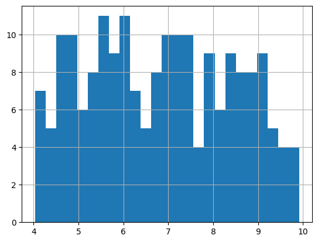

```python
ds["Sunlight_Hours"].hist(bins=25)
```

мені цей розподіл не дуже, тому подивимочь, чи години на сонці корелюють з іншими змінними

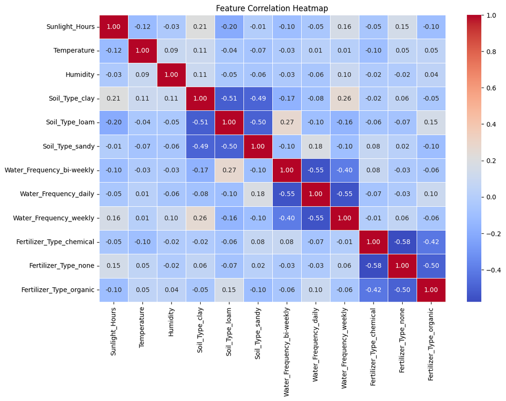

```python
import seaborn as sns
import matplotlib.pyplot as plt

corr_matrix = X_train_encoded.corr()

# Plot heatmap
plt.figure(figsize=(12, 8))
sns.heatmap(corr_matrix, annot=True, cmap='coolwarm', fmt=".2f", linewidths=0.5)
plt.title("Feature Correlation Heatmap")
plt.show()
```

А ше тут видно, шо створені через ван-гот змінні дуже корелюють, через шо потім можуть бути проблеми

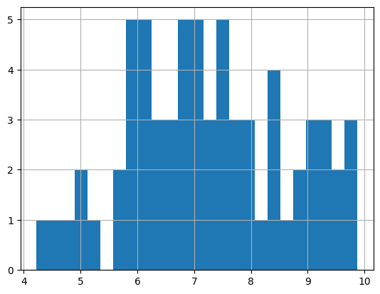

```python
# поглянем на розподіл сонечка для змінної з якою вона найбільше корелює
ds[ds["Soil_Type"] == "clay"]["Sunlight_Hours"].hist(bins=25)
```

```python
from sklearn.preprocessing import StandardScaler

scaler = StandardScaler()
X_train_encoded[num_cols] = scaler.fit_transform(X_train_encoded[num_cols])
X_test_encoded[num_cols] = scaler.fit_transform(X_test_encoded[num_cols])
```

```python
X_train_encoded.describe()
```

|  | Sunlight_Hours | Temperature | Humidity |
| --- | --- | --- | --- |
| count | 1.540000e+02 | 1.540000e+02 | 1.540000e+02 |
| mean | 1.032363e-15 | -2.465560e-16 | 6.228784e-16 |
| std | 1.003263e+00 | 1.003263e+00 | 1.003263e+00 |
| min | -1.704412e+00 | -1.903087e+00 | -2.139035e+00 |
| 25% | -8.254358e-01 | -7.252082e-01 | -7.193528e-01 |
| 50% | 1.477877e-02 | 1.534675e-01 | 7.221704e-02 |
| 75% | 7.903623e-01 | 8.407685e-01 | 8.698714e-01 |
| max | 1.966849e+00 | 1.722055e+00 | 1.654649e+00 |

даних мало, але побудуєм простенькі моделі для приблизної оцінки

```python
performance_table = {}
```

```python
from sklearn.linear_model import LogisticRegression
from sklearn.metrics import f1_score, accuracy_score, classification_report

lr_model = LogisticRegression()
lr_model.fit(X_train_encoded, y_train)
```

```
LogisticRegression()
```

```python
lr_pred = lr_model.predict(X_test_encoded)
f1_score(y_test, lr_pred), accuracy_score(y_test, lr_pred)
```

```
(0.5853658536585366, 0.5641025641025641)
```

```python
lr_model.__class__.__name__
```

```
'LogisticRegression'
```

```python
print(classification_report(y_test, lr_pred))
```

```
              precision    recall  f1-score   support

       False       0.50      0.59      0.54        17
        True       0.63      0.55      0.59        22

    accuracy                           0.56        39
   macro avg       0.57      0.57      0.56        39
weighted avg       0.57      0.56      0.57        39
```

```python
from sklearn.ensemble import RandomForestClassifier

rf_model = RandomForestClassifier()
rf_model.fit(X_train_encoded, y_train)
```

```
RandomForestClassifier()
```

```python
rf_pred = rf_model.predict(X_test_encoded)
f1_score(y_test, rf_pred), accuracy_score(y_test, rf_pred)
```

```
(0.6666666666666666, 0.6410256410256411)
```

```python
print(classification_report(y_test, rf_pred))
```

```
              precision    recall  f1-score   support

       False       0.58      0.65      0.61        17
        True       0.70      0.64      0.67        22

    accuracy                           0.64        39
   macro avg       0.64      0.64      0.64        39
weighted avg       0.65      0.64      0.64        39
```

```python
def test_model_performance(model) -> tuple[float, float]:
    model.fit(X_train_encoded, y_train)
    y_pred = model.predict(X_test_encoded)
    print(classification_report(y_test, y_pred))
    performance_table[model.__class__.__name__] = [f1_score(y_test, y_pred), accuracy_score(y_test, y_pred)]
    return f1_score(y_test, y_pred), accuracy_score(y_test, y_pred)
```

```python
test_model_performance(LogisticRegression())
```

```
              precision    recall  f1-score   support

       False       0.50      0.59      0.54        17
        True       0.63      0.55      0.59        22

    accuracy                           0.56        39
   macro avg       0.57      0.57      0.56        39
weighted avg       0.57      0.56      0.57        39
```

```
(0.5853658536585366, 0.5641025641025641)
```

```python
test_model_performance(RandomForestClassifier())
```

```
              precision    recall  f1-score   support

       False       0.56      0.53      0.55        17
        True       0.65      0.68      0.67        22

    accuracy                           0.62        39
   macro avg       0.61      0.61      0.61        39
weighted avg       0.61      0.62      0.61        39
```

```
(0.6666666666666666, 0.6153846153846154)
```

```python
from sklearn.svm import SVC

test_model_performance(SVC())
```

```
              precision    recall  f1-score   support

       False       0.53      0.53      0.53        17
        True       0.64      0.64      0.64        22

    accuracy                           0.59        39
   macro avg       0.58      0.58      0.58        39
weighted avg       0.59      0.59      0.59        39
```

```
(0.6363636363636364, 0.5897435897435898)
```

```python
pd.DataFrame(performance_table).T.rename({
    0: "F1", 1: "Accuracy",
}, axis = 1)
```

|  | F1 | Accuracy |
| --- | --- | --- |
| LogisticRegression | 0.585366 | 0.564103 |
| RandomForestClassifier | 0.666667 | 0.615385 |
| SVC | 0.636364 | 0.589744 |

найкращим вийшов рандом форест, запихнем його в GridSearch

```python
rf_model.get_params()
```

```
{'bootstrap': True,
 'ccp_alpha': 0.0,
 'class_weight': None,
 'criterion': 'gini',
 'max_depth': None,
 'max_features': 'sqrt',
 'max_leaf_nodes': None,
 'max_samples': None,
 'min_impurity_decrease': 0.0,
 'min_samples_leaf': 1,
 'min_samples_split': 2,
 'min_weight_fraction_leaf': 0.0,
 'monotonic_cst': None,
 'n_estimators': 100,
 'n_jobs': None,
 'oob_score': False,
 'random_state': None,
 'verbose': 0,
 'warm_start': False}
```

```python
from sklearn.model_selection import GridSearchCV

grid_model = GridSearchCV(
    estimator=RandomForestClassifier(),
    param_grid={
        'max_depth': [None, 10, 20],
        'n_estimators': [50, 100, 200],
    },
    cv=3,
)
grid_model.fit(X_train_encoded, y_train)
```

```
GridSearchCV(cv=3, estimator=RandomForestClassifier(),
             param_grid={'max_depth': [None, 10, 20],
                         'n_estimators': [50, 100, 200]})
```

```python
res = pd.DataFrame(grid_model.cv_results_)
res[res['rank_test_score'] == 1]
```

|  | mean_fit_time | std_fit_time | mean_score_time | std_score_time | param_max_depth | param_n_estimators | params | split0_test_score | split1_test_score | split2_test_score | mean_test_score | std_test_score | rank_test_score |
| --- | --- | --- | --- | --- | --- | --- | --- | --- | --- | --- | --- | --- | --- |
| 8 | 0.19631 | 0.007078 | 0.008977 | 0.000815 | 20 | 200 | {'max_depth': 20, 'n_estimators': 200} | 0.557692 | 0.784314 | 0.529412 | 0.623806 | 0.114082 | 1 |

```python
grid_model_2 = GridSearchCV(
    estimator=RandomForestClassifier(),
    param_grid={
        'max_depth': [None, 10, 20, 30],
        'n_estimators': [50, 100, 200, 300],
    },
    cv=5,
)
grid_model_2.fit(X_train_encoded, y_train)
```

```
GridSearchCV(cv=5, estimator=RandomForestClassifier(),
             param_grid={'max_depth': [None, 10, 20, 30],
                         'n_estimators': [50, 100, 200, 300]})
```

```python
res_2 = pd.DataFrame(grid_model_2.cv_results_)
res_2[res_2['rank_test_score'] == 1]
```

|  | mean_fit_time | std_fit_time | mean_score_time | std_score_time | param_max_depth | param_n_estimators | params | split0_test_score | split1_test_score | split2_test_score | split3_test_score | split4_test_score | mean_test_score | std_test_score | rank_test_score |
| --- | --- | --- | --- | --- | --- | --- | --- | --- | --- | --- | --- | --- | --- | --- | --- |
| 12 | 0.053855 | 0.001977 | 0.003596 | 0.000494 | 30 | 50 | {'max_depth': 30, 'n_estimators': 50} | 0.677419 | 0.548387 | 0.741935 | 0.483871 | 0.566667 | 0.603656 | 0.093095 | 1 |

```python
test_model_performance(RandomForestClassifier(max_depth=30, n_estimators=50))
```

```
              precision    recall  f1-score   support

       False       0.53      0.47      0.50        17
        True       0.62      0.68      0.65        22

    accuracy                           0.59        39
   macro avg       0.58      0.58      0.58        39
weighted avg       0.59      0.59      0.59        39
```

```
(0.6521739130434783, 0.5897435897435898)
```

метрики... не блестящі, але 65% F1 вже чучуть ліпше ніж рандом, подивимось шо зробить баєсівська модель

- Визначення структури мережі: побудувати граф структури мережі, який

задає зв'язки між змінними (BayesianModel([...])); аргументувати вибір напрямків між вузлами (на основі знань про предметну область або припущень).

```python
from pgmpy.models import DiscreteBayesianNetwork

from plotly.subplots import make_subplots
import plotly.graph_objects as go
import networkx as nx
```

explanation: https://www.youtube.com/watch?v=TuGDMj43ehw&ab_channel=BertHuang

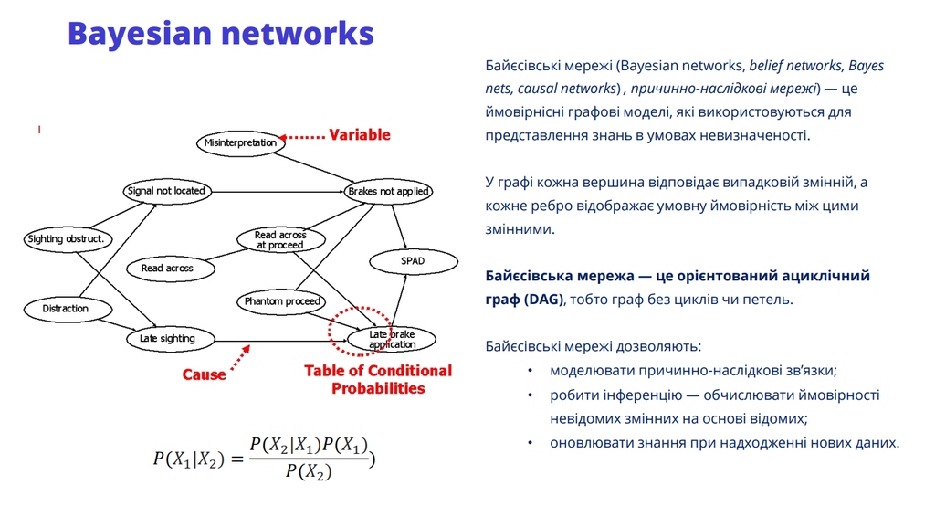

```python
X_clean = pd.get_dummies(X, columns=cat_cols, drop_first=False)
X_clean.sample(4)
```

|  | Sunlight_Hours | Temperature | Humidity | Soil_Type_clay | Soil_Type_loam | Soil_Type_sandy | Water_Frequency_bi-weekly | Water_Frequency_daily | Water_Frequency_weekly | Fertilizer_Type_chemical | Fertilizer_Type_none | Fertilizer_Type_organic |
| --- | --- | --- | --- | --- | --- | --- | --- | --- | --- | --- | --- | --- |
| 150 | 6.698 | 21.5 | 69.6 | True | False | False | False | True | False | False | True | False |
| 119 | 4.118 | 31.2 | 50.4 | False | False | True | True | False | False | False | True | False |
| 158 | 5.451 | 31.3 | 46.1 | False | False | True | False | True | False | False | True | False |
| 159 | 8.991 | 27.9 | 57.2 | True | False | False | True | False | False | False | False | True |

```python
X_clean[num_cols] = scaler.fit_transform(X_clean[num_cols])
X_clean.sample(4)
```

|  | Sunlight_Hours | Temperature | Humidity | Soil_Type_clay | Soil_Type_loam | Soil_Type_sandy | Water_Frequency_bi-weekly | Water_Frequency_daily | Water_Frequency_weekly | Fertilizer_Type_chemical | Fertilizer_Type_none | Fertilizer_Type_organic |
| --- | --- | --- | --- | --- | --- | --- | --- | --- | --- | --- | --- | --- |
| 88 | 0.967063 | 0.005423 | -1.001866 | True | False | False | False | True | False | True | False | False |
| 61 | -1.320889 | -0.692206 | 1.710394 | False | False | True | True | False | False | False | True | False |
| 48 | 0.256725 | -0.170596 | 0.730478 | True | False | False | False | False | True | True | False | False |
| 55 | 1.304787 | -1.627042 | 1.592361 | False | True | False | False | True | False | False | True | False |

```python
ds = X_clean.copy()
ds[target] = y
```

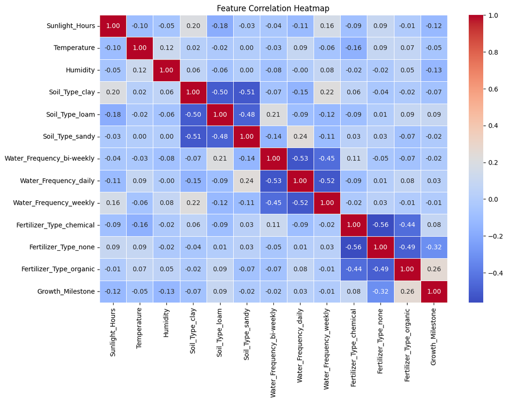

```python
corr_matrix = ds.corr()

# Plot heatmap
plt.figure(figsize=(12, 8))
sns.heatmap(corr_matrix, annot=True, cmap='coolwarm', fmt=".2f", linewidths=0.5)
plt.title("Feature Correlation Heatmap")
plt.show()
```

```python
ds["Sunlight_Hours"] = pd.cut(ds["Sunlight_Hours"], bins=3, labels=['few', 'medium', 'much'])
```

```python
ds["Temperature"] = pd.cut(ds["Temperature"], bins=3, labels=['low', 'medium', 'high'])
```

```python
ds["Humidity"] = pd.cut(ds["Humidity"], bins=2, labels=['low', 'high'])
```

```python
ds.sample(4)
```

|  | Sunlight_Hours | Temperature | Humidity | Soil_Type_clay | Soil_Type_loam | Soil_Type_sandy | Water_Frequency_bi-weekly | Water_Frequency_daily | Water_Frequency_weekly | Fertilizer_Type_chemical | Fertilizer_Type_none | Fertilizer_Type_organic | Growth_Milestone |
| --- | --- | --- | --- | --- | --- | --- | --- | --- | --- | --- | --- | --- | --- |
| 46 | few | medium | low | True | False | False | False | True | False | False | False | True | True |
| 171 | medium | high | high | True | False | False | False | False | True | False | False | True | True |
| 106 | few | medium | low | False | True | False | True | False | False | False | False | True | True |
| 154 | few | medium | high | False | True | False | False | False | True | False | True | False | False |

```python
bs_model = DiscreteBayesianNetwork([
    ("Sunlight_Hours", "Soil_Type_clay"),
    ("Sunlight_Hours", "Soil_Type_loam"),
    ("Sunlight_Hours", "Water_Frequency_weekly"),
    ("Temperature", "Fertilizer_Type_chemical"),
    ("Temperature", "Humidity"),
    ("Soil_Type_clay", "Water_Frequency_weekly"),
    ("Soil_Type_loam", "Water_Frequency_bi-weekly"),
    ("Water_Frequency_bi-weekly", "Soil_Type_sandy"),
    ("Growth_Milestone", "Fertilizer_Type_none"),
    ("Growth_Milestone", "Fertilizer_Type_organic"),
    ("Growth_Milestone", "Humidity"),
])
```

- Параметричне навчання: навчити параметри моделі на основі датасету за

допомогою BayesianEstimator або MaximumLikelihoodEstimator.

```python
# з методички
from pgmpy.estimators import MaximumLikelihoodEstimator

# Fit model using Maximum Likelihood Estimation
bs_model.fit(ds, estimator=MaximumLikelihoodEstimator)
```

[output not shown]

```
<pgmpy.models.DiscreteBayesianNetwork.DiscreteBayesianNetwork at 0x2f1b3f7d910>
```

- Виконання інференсу: реалізувати обчислення умовної ймовірності для

цільової змінної з урахуванням заданого evidence, використовуючи VariableElimination або BeliefPropagation.

```python
from pgmpy.inference import VariableElimination

# Create inference object
inference = VariableElimination(bs_model)
```

```python
# Query: Probability of survival given...
query_result = inference.query(
    variables=["Growth_Milestone"],
    evidence={
        "Fertilizer_Type_organic": True,
        #"Temperature": "high",
    }
)
print(query_result)
```

```
+-------------------------+-------------------------+
| Growth_Milestone        |   phi(Growth_Milestone) |
+=========================+=========================+
| Growth_Milestone(False) |                  0.2963 |
+-------------------------+-------------------------+
| Growth_Milestone(True)  |                  0.7037 |
+-------------------------+-------------------------+
```

```python
print("Nodes:", list(bs_model.nodes()))
print("Edges:", list(bs_model.edges()))
```

[output not shown]

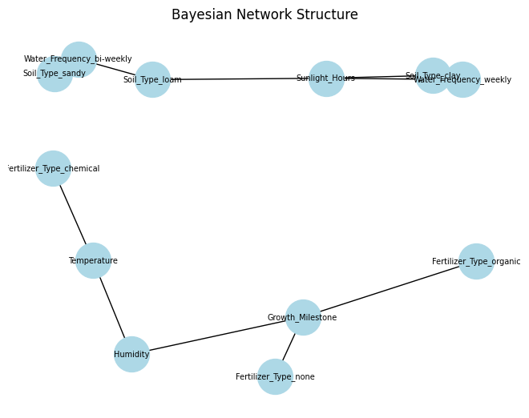

```python
import matplotlib.pyplot as plt
import networkx as nx

# Створюємо окремий граф із тієї ж структури
G = nx.DiGraph()
G.add_nodes_from(bs_model.nodes())
G.add_edges_from(bs_model.edges())

# Отримуємо layout
pos = nx.spring_layout(G)

# Малюємо граф
nx.draw(
    G,
    pos,
    with_labels=True,
    node_size=1000,
    node_color='lightblue',
    font_size=7,
    arrows=False,
)
plt.title("Bayesian Network Structure")
plt.show()
```

[figure not shown]

```python
from pyvis.network import Network
import html

net = Network(
    notebook=True,
    directed=True,
    height='800px',
    width='100%',
    bgcolor='#ffffff',
    font_color='black',
    cdn_resources='remote',
)

# Add nodes with larger size and font
for node in bs_model.nodes():
    try:
        cpd = bs_model.get_cpds(node)
        tooltip = f"{html.escape(str(cpd))}"
    except:
        tooltip = node
    net.add_node(
        node,
        label=node,
        title=tooltip,
        shape='dot',
        size=50,  # Increased from 25
        font={'size': 82}  # Larger font
    )

# Add edges
for edge in bs_model.edges():
    net.add_edge(*edge)

# Improve physics and layout
net.toggle_physics(True)
net.barnes_hut()

net.show("bayesian_network.html")
```

```
bayesian_network.html
```

[interactive chart not shown]